# Introduction to Statistics for Data Scientists

# Negative Binomial Examples

```r
require(ggplot2)
require(MASS) # For quine data
require(qdata)
```

## Example: Quine data

### Data description

Data is of 146 children from a large town in rural New South Wales, Australia.  
Five variables were collected:

- `Days`: number of days absent from school in a year
- `Age`: age in 4 levels
- `Eth`: aboriginal or non-aboriginal
- `Lrn`: slow learner (SL) or average learner (AL)
- `Sex`: sex of subject

### Data loading

The main aim of analysis is to model the number of absences in a year with the other variables.

```r
data(quine)
head(quine)
```

```
##   Eth Sex Age Lrn Days
## 1   A   M  F0  SL    2
## 2   A   M  F0  SL   11
## 3   A   M  F0  SL   14
## 4   A   M  F0  AL    5
## 5   A   M  F0  AL    5
## 6   A   M  F0  AL   13
```

```r
str(quine)
```

```
## 'data.frame':    146 obs. of  5 variables:
##  $ Eth : Factor w/ 2 levels "A","N": 1 1 1 1 1 1 1 1 1 1 ...
##  $ Sex : Factor w/ 2 levels "F","M": 2 2 2 2 2 2 2 2 2 2 ...
##  $ Age : Factor w/ 4 levels "F0","F1","F2",..: 1 1 1 1 1 1 1 1 2 2 ...
##  $ Lrn : Factor w/ 2 levels "AL","SL": 2 2 2 1 1 1 1 1 2 2 ...
##  $ Days: int  2 11 14 5 5 13 20 22 6 6 ...
```

```r
summary(quine)
```

```
##  Eth    Sex    Age     Lrn          Days
##  A:69   F:80   F0:27   AL:83   Min.   : 0.00
##  N:77   M:66   F1:46   SL:63   1st Qu.: 5.00
##                F2:40           Median :11.00
##                F3:33           Mean   :16.46
##                                3rd Qu.:22.75
##                                Max.   :81.00
```

### Inference and models

We can start modeling the number of days of absence by using a classical GLM Poisson model:

```r
quine_pois <- glm(Days ~ (Sex+Age+Eth+Lrn)^4, data = quine, family=poisson)
summary(quine_pois)
```

```
##
## Call:
## glm(formula = Days ~ (Sex + Age + Eth + Lrn)^4, family = poisson,
##     data = quine)
##
## Deviance Residuals:
##     Min       1Q   Median       3Q      Max
## -7.3872  -2.5129  -0.4205   1.7424   6.6783
##
## Coefficients: (4 not defined because of singularities)
##                       Estimate Std. Error z value Pr(>|z|)
## (Intercept)             3.0564     0.1085  28.178  < 2e-16 ***
## SexM                   -0.4914     0.1648  -2.982 0.002860 **
## AgeF1                  -0.6227     0.1712  -3.638 0.000275 ***
## AgeF2                  -2.3632     0.7154  -3.303 0.000955 ***
## AgeF3                  -0.3784     0.1393  -2.717 0.006592 **
## EthN                   -0.1386     0.1590  -0.872 0.383394
## LrnSL                  -1.9577     0.5875  -3.333 0.000860 ***
## SexM:AgeF1              0.4092     0.3038   1.347 0.178074
## SexM:AgeF2              3.1098     0.7296   4.262 2.02e-05 ***
## SexM:AgeF3              1.1145     0.2001   5.570 2.55e-08 ***
## SexM:EthN              -0.7524     0.2682  -2.806 0.005021 **
## SexM:LrnSL              1.5900     0.6305   2.522 0.011673 *
## AgeF1:EthN              0.1029     0.2408   0.427 0.669209
## AgeF2:EthN             -0.5546     1.2350  -0.449 0.653410
## AgeF3:EthN              0.0633     0.2008   0.315 0.752564
## AgeF1:LrnSL             2.6421     0.6059   4.361 1.30e-05 ***
## AgeF2:LrnSL             4.8585     0.9212   5.274 1.33e-07 ***
## AgeF3:LrnSL                 NA         NA      NA       NA
## EthN:LrnSL              2.2588     0.6314   3.578 0.000347 ***
## SexM:AgeF1:EthN        -0.3105     0.5432  -0.572 0.567587
## SexM:AgeF2:EthN         0.3469     1.2620   0.275 0.783401
## SexM:AgeF3:EthN         0.8329     0.3122   2.668 0.007627 **
## SexM:AgeF1:LrnSL       -2.4285     0.7100  -3.420 0.000626 ***
## SexM:AgeF2:LrnSL       -4.1914     0.9555  -4.387 1.15e-05 ***
## SexM:AgeF3:LrnSL            NA         NA      NA       NA
## SexM:EthN:LrnSL        -0.1639     0.7024  -0.233 0.815496
## AgeF1:EthN:LrnSL       -3.5493     0.6715  -5.286 1.25e-07 ***
## AgeF2:EthN:LrnSL       -3.3315     1.3856  -2.404 0.016202 *
## AgeF3:EthN:LrnSL            NA         NA      NA       NA
## SexM:AgeF1:EthN:LrnSL   2.1711     0.8924   2.433 0.014985 *
## SexM:AgeF2:EthN:LrnSL   2.1029     1.4330   1.467 0.142254
## SexM:AgeF3:EthN:LrnSL       NA         NA      NA       NA
## ---
## Signif. codes:  0 '***' 0.001 '**' 0.01 '*' 0.05 '.' 0.1 ' ' 1
##
## (Dispersion parameter for poisson family taken to be 1)
##
##     Null deviance: 2073.5  on 145  degrees of freedom
## Residual deviance: 1173.9  on 118  degrees of freedom
## AIC: 1818.4
##
## Number of Fisher Scoring iterations: 5
```

For simplicity, we try to reduce we don’t go in details on the final model structure, and we analyze the residual plot.

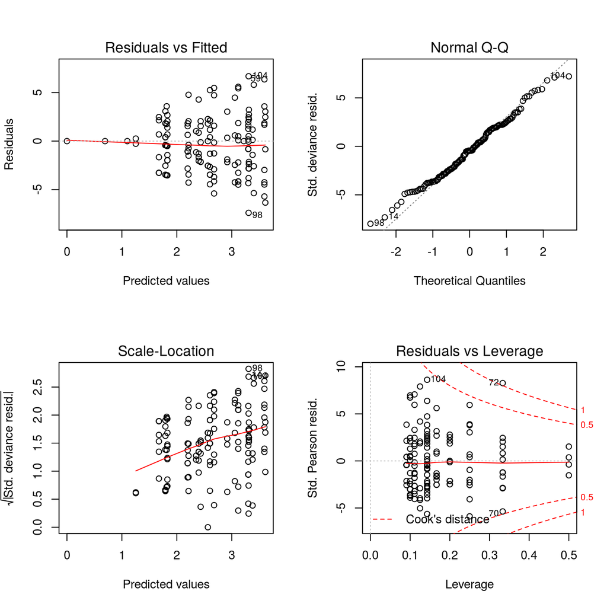

```r
op <- par(mfrow=c(2,2))
plot(quine_pois)
par(op)
```

Then, we will try a negative binomial model with the `glm.nb()` function of the MASS package:

```r
quine_nb0 <- glm.nb(Days ~ Sex*Age*Eth*Lrn, data = quine)
```

The default link for Negative Binomial family is “`log`”. Other available link functions are `link="sqrt"` or `link="identity"`.

Now, let us quickly reduce the model

```r
dropterm(quine_nb0, test="Chisq")
```

```
## Single term deletions
##
## Model:
## Days ~ Sex * Age * Eth * Lrn
##                 Df    AIC    LRT Pr(Chi)
## <none>             1095.3
## Sex:Age:Eth:Lrn  2 1092.7 1.4038  0.4956
```

```r
quine_nb1 <- update(quine_nb0, . ~ . - Sex:Age:Eth:Lrn, data=quine)
dropterm(quine_nb1, test="Chisq")
```

```
## Single term deletions
##
## Model:
## Days ~ Sex + Age + Eth + Lrn + Sex:Age + Sex:Eth + Age:Eth +
##     Sex:Lrn + Age:Lrn + Eth:Lrn + Sex:Age:Eth + Sex:Age:Lrn +
##     Sex:Eth:Lrn + Age:Eth:Lrn
##             Df    AIC    LRT Pr(Chi)
## <none>         1092.7
## Sex:Age:Eth  3 1089.4 2.6809 0.44348
## Sex:Age:Lrn  2 1095.0 6.2792 0.04330 *
## Sex:Eth:Lrn  1 1093.3 2.5959 0.10714
## Age:Eth:Lrn  2 1094.7 5.9736 0.05045 .
## ---
## Signif. codes:  0 '***' 0.001 '**' 0.01 '*' 0.05 '.' 0.1 ' ' 1
```

```r
quine_nb2 <- update(quine_nb1, . ~ . - Sex:Age:Eth, data=quine)
dropterm(quine_nb2, test="Chisq")
```

```
## Single term deletions
##
## Model:
## Days ~ Sex + Age + Eth + Lrn + Sex:Age + Sex:Eth + Age:Eth +
##     Sex:Lrn + Age:Lrn + Eth:Lrn + Sex:Age:Lrn + Sex:Eth:Lrn +
##     Age:Eth:Lrn
##             Df    AIC    LRT Pr(Chi)
## <none>         1089.4
## Sex:Age:Lrn  2 1091.1 5.7019 0.05779 .
## Sex:Eth:Lrn  1 1092.5 5.0384 0.02479 *
## Age:Eth:Lrn  2 1091.2 5.7684 0.05590 .
## ---
## Signif. codes:  0 '***' 0.001 '**' 0.01 '*' 0.05 '.' 0.1 ' ' 1
```

```r
quine_nb3 <- update(quine_nb2, . ~ . - Sex:Age:Lrn, data=quine)
dropterm(quine_nb3, test="Chisq")
```

```
## Single term deletions
##
## Model:
## Days ~ Sex + Age + Eth + Lrn + Sex:Age + Sex:Eth + Age:Eth +
##     Sex:Lrn + Age:Lrn + Eth:Lrn + Sex:Eth:Lrn + Age:Eth:Lrn
##             Df    AIC     LRT   Pr(Chi)
## <none>         1091.1
## Sex:Age      3 1104.8 19.6897 0.0001968 ***
## Sex:Eth:Lrn  1 1094.6  5.4881 0.0191463 *
## Age:Eth:Lrn  2 1091.4  4.3201 0.1153202
## ---
## Signif. codes:  0 '***' 0.001 '**' 0.01 '*' 0.05 '.' 0.1 ' ' 1
```

```r
quine_nb4 <- update(quine_nb3, . ~ . - Age:Eth:Lrn, data=quine)
dropterm(quine_nb4, test="Chisq")
```

```
## Single term deletions
##
## Model:
## Days ~ Sex + Age + Eth + Lrn + Sex:Age + Sex:Eth + Age:Eth +
##     Sex:Lrn + Age:Lrn + Eth:Lrn + Sex:Eth:Lrn
##             Df    AIC     LRT  Pr(Chi)
## <none>         1091.4
## Sex:Age      3 1106.6 21.1434 9.83e-05 ***
## Age:Eth      3 1090.8  5.3907 0.145324
## Age:Lrn      2 1091.2  3.7878 0.150482
## Sex:Eth:Lrn  1 1098.5  9.1154 0.002535 **
## ---
## Signif. codes:  0 '***' 0.001 '**' 0.01 '*' 0.05 '.' 0.1 ' ' 1
```

```r
quine_nb5 <- update(quine_nb4, . ~ . - Age:Lrn, data=quine)
dropterm(quine_nb5, test="Chisq")
```

```
## Single term deletions
##
## Model:
## Days ~ Sex + Age + Eth + Lrn + Sex:Age + Sex:Eth + Age:Eth +
##     Sex:Lrn + Eth:Lrn + Sex:Eth:Lrn
##             Df    AIC     LRT   Pr(Chi)
## <none>         1091.2
## Sex:Age      3 1103.7 18.4399 0.0003569 ***
## Age:Eth      3 1091.0  5.8064 0.1214197
## Sex:Eth:Lrn  1 1097.7  8.4389 0.0036727 **
## ---
## Signif. codes:  0 '***' 0.001 '**' 0.01 '*' 0.05 '.' 0.1 ' ' 1
```

```r
quine_nb <- update(quine_nb5, . ~ . - Age:Eth, data=quine)
dropterm(quine_nb, test="Chisq")
```

```
## Single term deletions
##
## Model:
## Days ~ Sex + Age + Eth + Lrn + Sex:Age + Sex:Eth + Sex:Lrn +
##     Eth:Lrn + Sex:Eth:Lrn
##             Df    AIC    LRT   Pr(Chi)
## <none>         1091.0
## Sex:Age      3 1103.6 18.619 0.0003277 ***
## Sex:Eth:Lrn  1 1101.5 12.422 0.0004244 ***
## ---
## Signif. codes:  0 '***' 0.001 '**' 0.01 '*' 0.05 '.' 0.1 ' ' 1
```

```r
summary(quine_nb)
```

```
##
## Call:
## glm.nb(formula = Days ~ Sex + Age + Eth + Lrn + Sex:Age + Sex:Eth +
##     Sex:Lrn + Eth:Lrn + Sex:Eth:Lrn, data = quine, init.theta = 1.597990736,
##     link = log)
##
## Deviance Residuals:
##     Min       1Q   Median       3Q      Max
## -2.8950  -0.8827  -0.2299   0.5669   2.1071
##
## Coefficients:
##                 Estimate Std. Error z value Pr(>|z|)
## (Intercept)      3.01919    0.29706  10.163  < 2e-16 ***
## SexM            -0.47541    0.39550  -1.202 0.229355
## AgeF1           -0.70887    0.32321  -2.193 0.028290 *
## AgeF2           -0.61486    0.37141  -1.655 0.097826 .
## AgeF3           -0.34235    0.32717  -1.046 0.295388
## EthN            -0.07312    0.26539  -0.276 0.782908
## LrnSL            0.94358    0.32246   2.926 0.003432 **
## SexM:AgeF1      -0.01486    0.46225  -0.032 0.974353
## SexM:AgeF2       1.24328    0.46134   2.695 0.007040 **
## SexM:AgeF3       1.49319    0.45337   3.294 0.000989 ***
## SexM:EthN       -0.60586    0.36896  -1.642 0.100572
## SexM:LrnSL      -0.70467    0.46536  -1.514 0.129966
## EthN:LrnSL      -1.35849    0.37719  -3.602 0.000316 ***
## SexM:EthN:LrnSL  2.11991    0.58056   3.651 0.000261 ***
## ---
## Signif. codes:  0 '***' 0.001 '**' 0.01 '*' 0.05 '.' 0.1 ' ' 1
##
## (Dispersion parameter for Negative Binomial(1.598) family taken to be 1)
##
##     Null deviance: 234.56  on 145  degrees of freedom
## Residual deviance: 167.56  on 132  degrees of freedom
## AIC: 1093
##
## Number of Fisher Scoring iterations: 1
##
##
##               Theta:  1.598
##           Std. Err.:  0.213
##
##  2 x log-likelihood:  -1063.025
```

```r
c(quine_nb$theta, quine_nb$SE.theta)
```

```
## [1] 1.5979907 0.2128654
```

Notice that the size `theta` ($\theta$) is also estimated. Theta is the $r$ parameter in our theoretical description (see last paragraph of relative chapter).

The comparison between full model (`quine_nb0`) and last model (`quine_nb`) returns:

```r
anova(quine_nb, quine_nb0, test="Chisq")
```

```
## Likelihood ratio tests of Negative Binomial Models
##
## Response: Days
##                                                                         Model
## 1 Sex + Age + Eth + Lrn + Sex:Age + Sex:Eth + Sex:Lrn + Eth:Lrn + Sex:Eth:Lrn
## 2                                                       Sex * Age * Eth * Lrn
##      theta Resid. df    2 x log-lik.   Test    df LR stat.   Pr(Chi)
## 1 1.597991       132       -1063.025
## 2 1.928360       118       -1039.324 1 vs 2    14   23.701 0.0497771
```

which is marginally significant.

If we want to compare this last model with an equivalent Poisson model (`quine_pois`) we obtain:

```r
quine_pois=glm(Days~Sex*(Age+Eth*Lrn),family = poisson(),data=quine)
summary(quine_pois)
```

```
##
## Call:
## glm(formula = Days ~ Sex * (Age + Eth * Lrn), family = poisson(),
##     data = quine)
##
## Deviance Residuals:
##     Min       1Q   Median       3Q      Max
## -7.3924  -2.4923  -0.5745   1.5507   8.5631
##
## Coefficients:
##                 Estimate Std. Error z value Pr(>|z|)
## (Intercept)      2.89964    0.08662  33.476  < 2e-16 ***
## SexM            -0.39728    0.12016  -3.306 0.000945 ***
## AgeF1           -0.48941    0.09609  -5.093 3.52e-07 ***
## AgeF2           -0.19579    0.10595  -1.848 0.064612 .
## AgeF3           -0.21627    0.09775  -2.213 0.026931 *
## EthN            -0.08595    0.08523  -1.008 0.313232
## LrnSL            0.73625    0.09548   7.711 1.25e-14 ***
## EthN:LrnSL      -1.27702    0.12645 -10.099  < 2e-16 ***
## SexM:AgeF1      -0.33326    0.15790  -2.111 0.034805 *
## SexM:AgeF2       0.82205    0.13398   6.136 8.48e-10 ***
## SexM:AgeF3       1.23318    0.13490   9.141  < 2e-16 ***
## SexM:EthN       -0.40470    0.11316  -3.576 0.000348 ***
## SexM:LrnSL      -0.39846    0.13266  -3.004 0.002667 **
## SexM:EthN:LrnSL  1.86724    0.17693  10.554  < 2e-16 ***
## ---
## Signif. codes:  0 '***' 0.001 '**' 0.01 '*' 0.05 '.' 0.1 ' ' 1
##
## (Dispersion parameter for poisson family taken to be 1)
##
##     Null deviance: 2073.5  on 145  degrees of freedom
## Residual deviance: 1393.5  on 132  degrees of freedom
## AIC: 2010
##
## Number of Fisher Scoring iterations: 5
```

```r
pchisq(2*(logLik(quine_nb)-logLik(quine_pois)), df=1, lower.tail=F)
```

```
## 'log Lik.' 7.357578e-202 (df=15)
```

Anyway, this test is not really adequate, since theta=+Inf is on the boundary of parameter space, and thus the LRT is not applicable.

We could reduce the model also with the `step()` function, as for LM and GLM models:

```r
quine_nb_step <- step(quine_nb0)
```

```
## Start:  AIC=1095.32
## Days ~ Sex * Age * Eth * Lrn
##
##                   Df Deviance    AIC
## - Sex:Age:Eth:Lrn  2   168.86 1092.7
## <none>                 167.45 1095.3
##
## Step:  AIC=1092.73
## Days ~ Sex + Age + Eth + Lrn + Sex:Age + Sex:Eth + Age:Eth +
##     Sex:Lrn + Age:Lrn + Eth:Lrn + Sex:Age:Eth + Sex:Age:Lrn +
##     Sex:Eth:Lrn + Age:Eth:Lrn
##
##               Df Deviance    AIC
## - Sex:Age:Eth  3   170.26 1089.4
## <none>             167.55 1092.7
## - Sex:Eth:Lrn  1   170.16 1093.3
## - Age:Eth:Lrn  2   173.66 1094.8
## - Sex:Age:Lrn  2   173.94 1095.1
##
## Step:  AIC=1089.41
## Days ~ Sex + Age + Eth + Lrn + Sex:Age + Sex:Eth + Age:Eth +
##     Sex:Lrn + Age:Lrn + Eth:Lrn + Sex:Age:Lrn + Sex:Eth:Lrn +
##     Age:Eth:Lrn
##
##               Df Deviance    AIC
## <none>             167.44 1089.4
## - Sex:Age:Lrn  2   173.23 1091.2
## - Age:Eth:Lrn  2   173.33 1091.3
## - Sex:Eth:Lrn  1   172.57 1092.5
```

```r
summary(quine_nb_step)
```

```
##
## Call:
## glm.nb(formula = Days ~ Sex + Age + Eth + Lrn + Sex:Age + Sex:Eth +
##     Age:Eth + Sex:Lrn + Age:Lrn + Eth:Lrn + Sex:Age:Lrn + Sex:Eth:Lrn +
##     Age:Eth:Lrn, data = quine, init.theta = 1.865343469, link = log)
##
## Deviance Residuals:
##     Min       1Q   Median       3Q      Max
## -3.1387  -0.9777  -0.2000   0.5349   1.7630
##
## Coefficients: (3 not defined because of singularities)
##                  Estimate Std. Error z value Pr(>|z|)
## (Intercept)        3.1693     0.3411   9.292  < 2e-16 ***
## SexM              -0.6920     0.4138  -1.672 0.094459 .
## AgeF1             -0.6405     0.4638  -1.381 0.167329
## AgeF2             -2.4576     0.8675  -2.833 0.004612 **
## AgeF3             -0.5880     0.3973  -1.480 0.138885
## EthN              -0.3560     0.4210  -0.845 0.397848
## LrnSL             -1.0264     0.7378  -1.391 0.164179
## SexM:AgeF1         0.2985     0.6047   0.494 0.621597
## SexM:AgeF2         3.2904     0.8941   3.680 0.000233 ***
## SexM:AgeF3         1.5412     0.4548   3.389 0.000702 ***
## SexM:EthN         -0.3562     0.3854  -0.924 0.355364
## AgeF1:EthN         0.1500     0.5644   0.266 0.790400
## AgeF2:EthN        -0.3833     0.5640  -0.680 0.496746
## AgeF3:EthN         0.4719     0.4542   1.039 0.298824
## SexM:LrnSL         0.5457     0.8013   0.681 0.495873
## AgeF1:LrnSL        1.6231     0.8222   1.974 0.048373 *
## AgeF2:LrnSL        3.8321     1.1054   3.467 0.000527 ***
## AgeF3:LrnSL            NA         NA      NA       NA
## EthN:LrnSL         0.9651     0.7753   1.245 0.213255
## SexM:AgeF1:LrnSL  -1.1086     0.9409  -1.178 0.238671
## SexM:AgeF2:LrnSL  -2.8800     1.1550  -2.493 0.012651 *
## SexM:AgeF3:LrnSL       NA         NA      NA       NA
## SexM:EthN:LrnSL    1.3578     0.5914   2.296 0.021684 *
## AgeF1:EthN:LrnSL  -2.1013     0.8728  -2.408 0.016058 *
## AgeF2:EthN:LrnSL  -1.8260     0.8774  -2.081 0.037426 *
## AgeF3:EthN:LrnSL       NA         NA      NA       NA
## ---
## Signif. codes:  0 '***' 0.001 '**' 0.01 '*' 0.05 '.' 0.1 ' ' 1
##
## (Dispersion parameter for Negative Binomial(1.8653) family taken to be 1)
##
##     Null deviance: 265.27  on 145  degrees of freedom
## Residual deviance: 167.44  on 123  degrees of freedom
## AIC: 1091.4
##
## Number of Fisher Scoring iterations: 1
##
##
##               Theta:  1.865
##           Std. Err.:  0.258
##
##  2 x log-likelihood:  -1043.409
```

step() provides a different model in this case, with two 3-way interactions more

```r
anova(quine_nb_step, quine_nb)
```

```
## Likelihood ratio tests of Negative Binomial Models
##
## Response: Days
##                                                                                                                         Model
## 1                                                 Sex + Age + Eth + Lrn + Sex:Age + Sex:Eth + Sex:Lrn + Eth:Lrn + Sex:Eth:Lrn
## 2 Sex + Age + Eth + Lrn + Sex:Age + Sex:Eth + Age:Eth + Sex:Lrn + Age:Lrn + Eth:Lrn + Sex:Age:Lrn + Sex:Eth:Lrn + Age:Eth:Lrn
##      theta Resid. df    2 x log-lik.   Test    df LR stat.    Pr(Chi)
## 1 1.597991       132       -1063.025
## 2 1.865343       123       -1043.409 1 vs 2     9 19.61623 0.02043423
```

3-way interactions added are significant with alpha=0.05 but not with alpha=0.01 They have also some missing cells: it is arguable whether keep `quine_nb_step` or `quine_nb`.

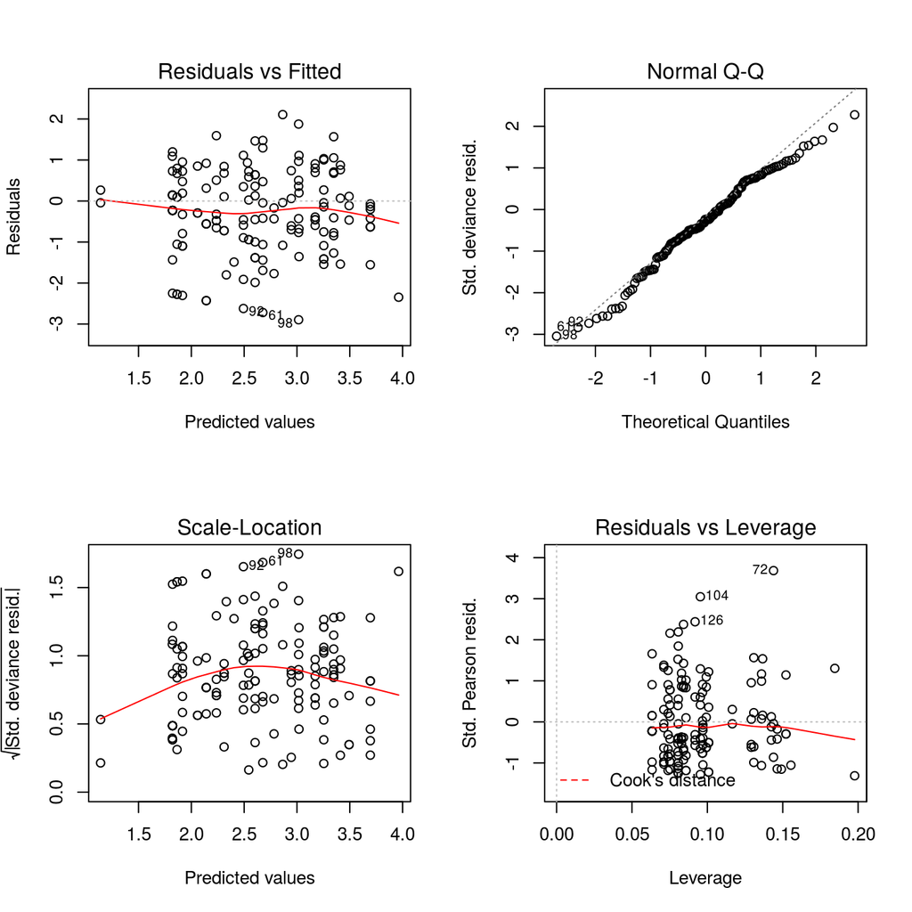

```r
op <- par(mfrow=c(2,2))
plot(quine_nb)
par(op)
```

Residuals now are surely much better than in Poisson model.

## Example: Negative Binomial vs Poisson

We can see what happens when we fit a negative binomial model when a Poisson model actually works.  
Let us create a fictitious dataset with Poisson dependent variable and a simple linear model that relates independent variable and dependent variable:

```r
set.seed(123)
x <- runif(n=300, min=10, max=40)
set.seed(123)
y <- sapply(x, function(xx) rpois(n=1, lambda=exp(.5+.05*xx)))
```

Let us plot the data:

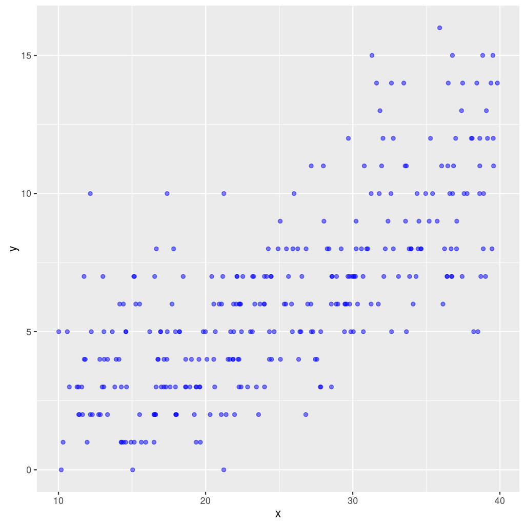

```r
ggp <- ggplot(data = data.frame(x=x,y=y), mapping = aes(x=x,y=y)) +
  geom_point(colour="blue", alpha=0.5)
print(ggp)
```

And then we estimate the Poisson model:

```r
fit <- glm(y ~ x, family=poisson)
summary(fit)
```

```
##
## Call:
## glm(formula = y ~ x, family = poisson)
##
## Deviance Residuals:
##     Min       1Q   Median       3Q      Max
## -3.1012  -0.6882  -0.1095   0.5448   3.0912
##
## Coefficients:
##             Estimate Std. Error z value Pr(>|z|)
## (Intercept) 0.554401   0.083745    6.62 3.59e-11 ***
## x           0.047850   0.002843   16.83  < 2e-16 ***
## ---
## Signif. codes:  0 '***' 0.001 '**' 0.01 '*' 0.05 '.' 0.1 ' ' 1
##
## (Dispersion parameter for poisson family taken to be 1)
##
##     Null deviance: 567.39  on 299  degrees of freedom
## Residual deviance: 273.28  on 298  degrees of freedom
## AIC: 1331.9
##
## Number of Fisher Scoring iterations: 4
```

```r
pchisq(fit$deviance, fit$df.residual, lower.tail = FALSE)
```

```
## [1] 0.8448518
```

And the Negative Binomial model:

```r
fit.nb <- glm.nb(y ~ x)
summary(fit.nb)
```

```
##
## Call:
## glm.nb(formula = y ~ x, init.theta = 78974.04118, link = log)
##
## Deviance Residuals:
##     Min       1Q   Median       3Q      Max
## -3.1012  -0.6882  -0.1095   0.5448   3.0911
##
## Coefficients:
##             Estimate Std. Error z value Pr(>|z|)
## (Intercept) 0.554400   0.083749    6.62  3.6e-11 ***
## x           0.047850   0.002843   16.83  < 2e-16 ***
## ---
## Signif. codes:  0 '***' 0.001 '**' 0.01 '*' 0.05 '.' 0.1 ' ' 1
##
## (Dispersion parameter for Negative Binomial(78974.04) family taken to be 1)
##
##     Null deviance: 567.34  on 299  degrees of freedom
## Residual deviance: 273.26  on 298  degrees of freedom
## AIC: 1333.9
##
## Number of Fisher Scoring iterations: 1
##
##
##               Theta:  78974
##           Std. Err.:  664782
## Warning while fitting theta: iteration limit reached
##
##  2 x log-likelihood:  -1327.901
```

The estimate of theta is large and with a very large standard error. This may be an indication that the Negative Binomial model is an over-parameterized model to fit data, and Poisson model is better.